# Increasing Awareness in Distance-Based Learning

Alfonso Iodice D’Enza

2026-09-16

## A collaborative project

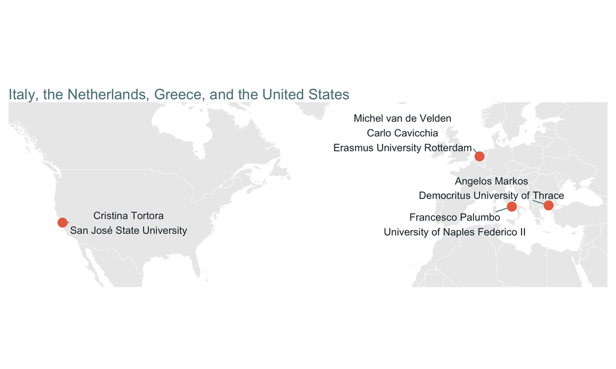

## Outline

**1. Distance-based learning with mixed data**  
Increasing awareness in distance construction

**2. Scale/type-aware distances**  
Additivity, commensurability, and bias in mixed data

**3. Association-aware distances**  
Redundancy, correlations, and categorical associations

**4. Interaction- and response-aware extensions**  
Continuous–categorical relationships and supervised neighbourhoods

# 1. Distance-based learning with mixed data

## Mixed-type data

Most real data applications do not contain only numerical variables.

**Tabular data**

In socio-economic applications, observations are often described by a mixture of  
**measurements**, **counts**, **categories**, and **ordered scales**.

**Numerical variables**

- income
- age
- prices
- growth rates
- emissions
- employment rates

**Categorical variables**

- region
- education level
- occupation
- sector
- household type
- policy regime

## Learning from mixed-type data

Many statistical learning methods rely, explicitly or implicitly, on **comparing observations**.

- If the data are mixed-type, then comparison is **not straightforward**:

**Scale**

How do we compare variables measured in different units?

**Type**

How do we combine numerical differences with category mismatches?

**Structure**

How do we avoid counting associated information multiple times?

### the aim is to compare observations while accounting for scale, type, and structure

## Learning from distances

**Terminology alert!**

I will often use **distance** as shorthand for pairwise dissimilarity.

Some measures discussed here are not metrics in the strict mathematical sense,  
but they all quantify how different two observations are.

Many learning methods can operate directly on a dissimilarity matrix.

**Dimension reduction**

Multidimensional scaling (MDS)<sup>1</sup>

**Clustering methods**

Hierarchical clustering (HC), PAM<sup>2</sup>, and spectral clustering<sup>3</sup>

**Nearest-neighbour prediction**

Nearest-neighbour classification and nearest-neighbour averaging for regression

### choosing a different distance can lead to a different downstream analysis result

[^1]: Borg & Groenen (2005)
[^2]: Kaufman & Rousseeuw (2009)
[^3]: Ng, Jordan, & Weiss (2002)

## building pairwise dissimilarities: **intuition**

2 continuous variables: add up by-variable (absolute value or squared) differences

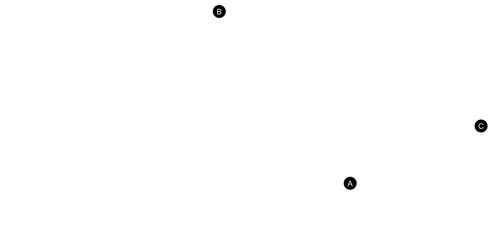

## building pairwise dissimilarities: **intuition**

2 continuous variables: add up by-variable (absolute value or squared) differences

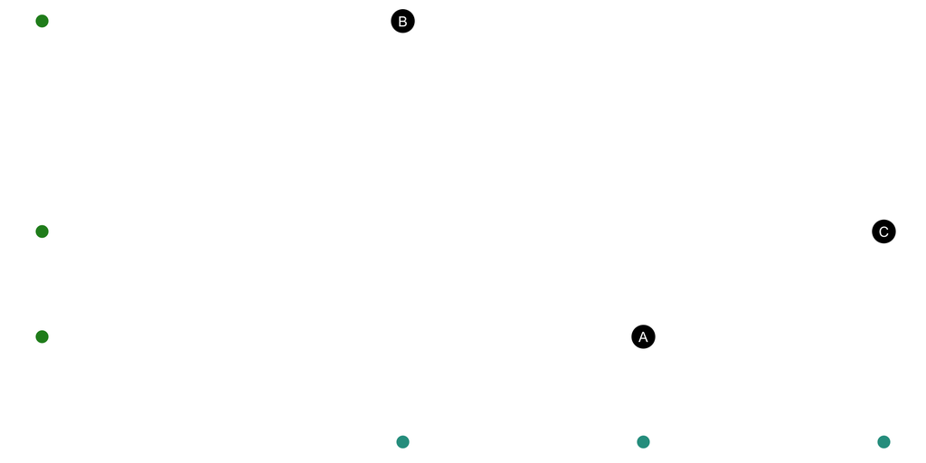

## building pairwise dissimilarities: **intuition**

2 continuous variables: add up by-variable (absolute value or squared) differences

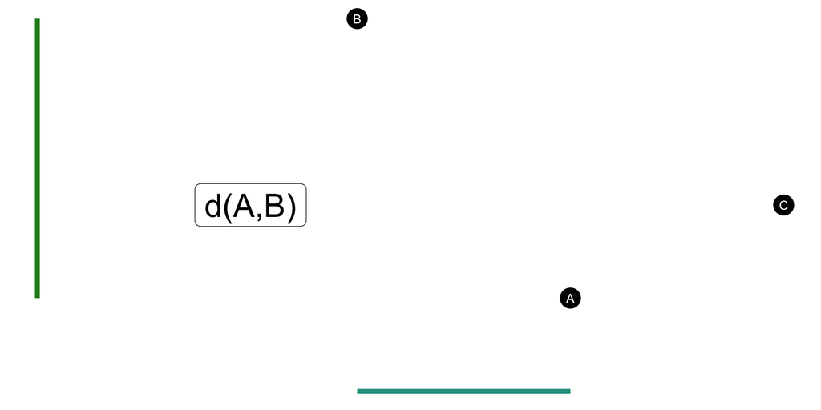

## building pairwise dissimilarities: **intuition**

2 continuous variables: add up by-variable (absolute value or squared) differences

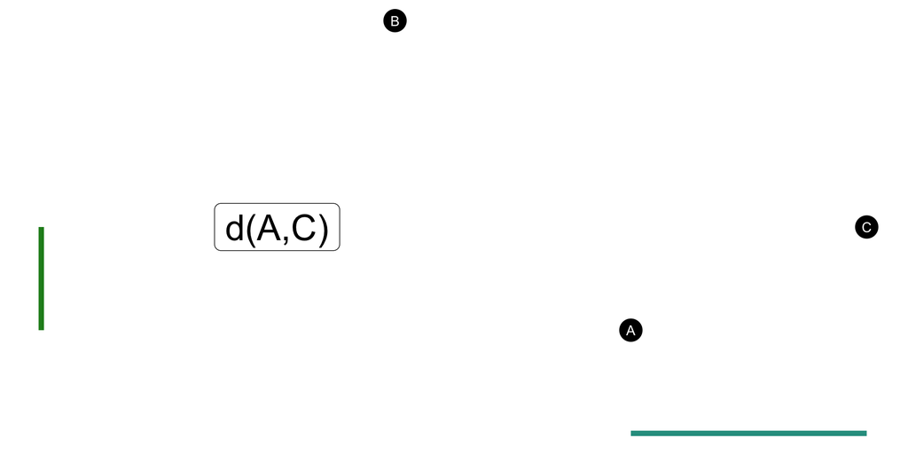

## building pairwise dissimilarities: **intuition**

2 continuous variables: add up by-variable (absolute value or squared) differences

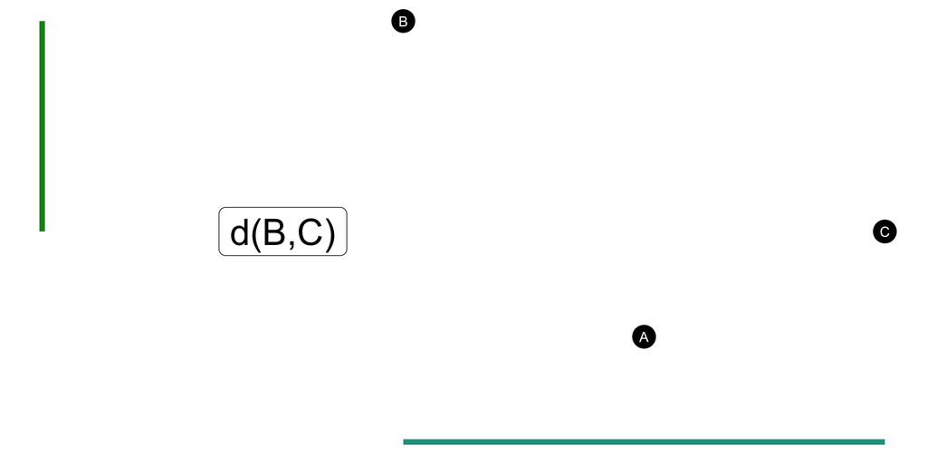

## building pairwise dissimilarities: **intuition**

2 continuous and 1 categorical variables

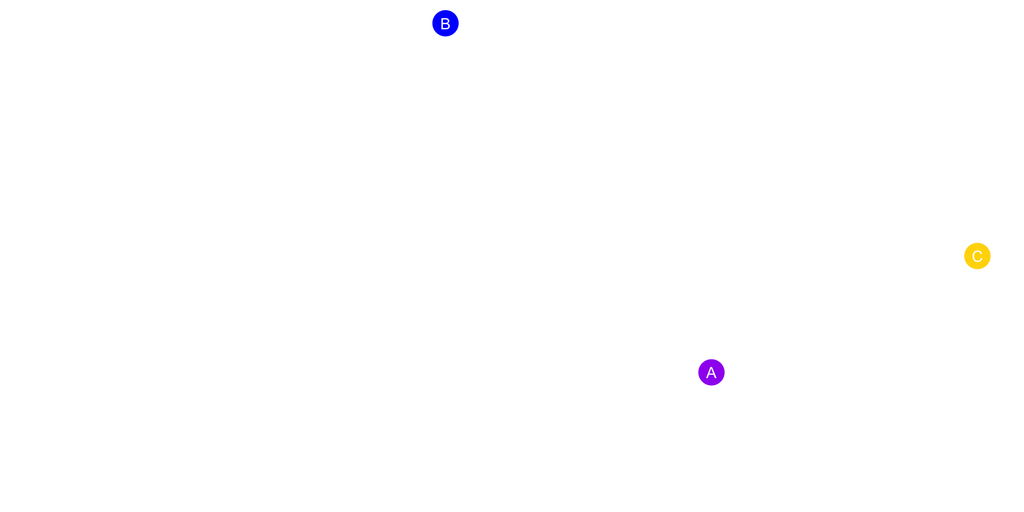

## building pairwise dissimilarities: **intuition**

one might consider purple and blue *closer* than e.g. purple and yellow

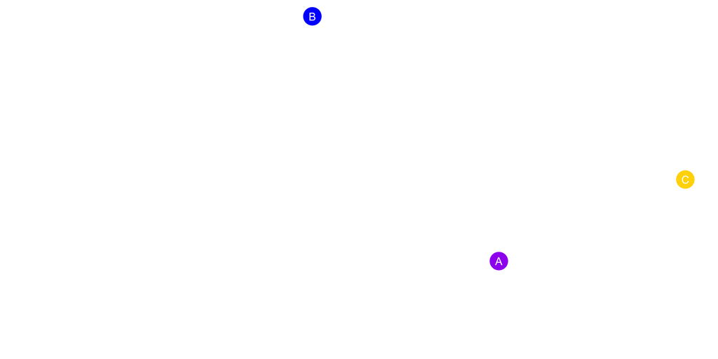

# 2. Scale/type-aware distances

## Desirable properties<sup>1</sup>

**Multivariate Additivity**

Let $\mathbf{x}_i=\left(x_{i1}, \dots, x_{iQ}\right)$ denote a $Q-$dimensional vector. A distance function $d\left(\mathbf{x}_i,\mathbf{x}_\ell\right)$ between observations $i$ and $\ell$ is multivariate additive if

$$d\left(\mathbf{x}_i,\mathbf{x}_\ell\right)=\sum_{j=1}^{Q} d_j\left(\mathbf{x}_i,\mathbf{x}_\ell\right),$$

where $d_j\left(\mathbf{x}_i,\mathbf{x}_\ell\right)$ denotes the $j-$th variable specific distance.

- **Manhattan** distance satisfies the additivity property; the **Euclidean** distance does not
[^4]: van de Velden, Iodice D’Enza, Markos, & Cavicchia (2026)

## Desirable properties<sup>1</sup>

If additivity holds, by-variable distances are added together: they should be on equivalent scales

**Commensurability**

Let ${\boldsymbol X}_i =\left(X_{i1}, \dots, X_{iQ}\right)$ denote a $Q-$dimensional random variable corresponding to an observation $i$. Furthermore, let $d_{j}$ denote the distance function corresponding to the $j-$th variable.

We have commensurability if, for all $j$, and $i \neq \ell$,

$$E[d_{j}({ X}_{ij}, {X}_{\ell j})] = c,$$

where $c$ is some constant.

[^5]: van de Velden et al. (2026)

## Desirable properties<sup>1</sup>

If the multivariate distance function $d(\cdot,\cdot)$ satisfies additivity and commensurability, then *ad hoc* distance functions can be used for each variable and then aggregated.

then

> one can pick the appropriate $d_{j}(\cdot,\cdot)$, given the nature of $X_{j}$
> - well suited in the mixed data case
[^6]: van de Velden et al. (2026)

## Mixed-data setup

**a mixed data set**

- $I$ observations described by $Q$ variables, $Q_{n}$ numerical and $Q_{c}$ categorical
- the $I\times Q$ data matrix ${\bf X}=\left[{\bf X}_{n},{\bf X}_{c}\right]$ is column-wise partitioned

A formulation for mixed distance between observations $i$ and $\ell$:

$$\begin{eqnarray}\label{genmixeddist_formula}
d\left(\mathbf{x}_i,\mathbf{x}_\ell\right)&=& \sum_{j_n=1}^{Q_n} d_{j_n}\left(\mathbf{x}^n_i,\mathbf{x}^n_\ell\right)+ \sum_{j_c=1}^{Q_c} d_{j_c}\left(\mathbf{x}^c_i,\mathbf{x}^c_\ell\right)=\\
&=& \sum_{j_n=1}^{Q_n} w_{j_n} \delta^n_{j_n}\left(\mathbf{x}^n_i,\mathbf{x}^n_\ell\right)+ \sum_{j_c=1}^{Q_c} w_{j_c}\delta^c_{j_c}\left(\mathbf{x}^c_i,\mathbf{x}^c_\ell\right)
\end{eqnarray}$$

**numeric case**

- $\delta^n_{j_n}$ is a function quantifying the dissimilarity between observations on the $j_n-$th numerical variable
- $w_{j_n}$ is a weight for the $j_n-$th variable.

**categorical case**

dissimilarity between the categories chosen by subjects $i$ and $\ell$ for categorical variable $j_c$

- $w_{j_c}$ is a weight for the $j_c-$th variable

## Distributions, scaling and bias: the numeric case

**Synthetic data**

- $I=500$ observations from `normal`, `uniform`, `skewed`, and `bimodal` distributions
- `skewed` refers to a $\chi^2_{1/2}$ distribution
- `bimodal`: $n/2$ draws from $\chi^2_{1/2}$, censored at $10$, and $n/2$ draws from $10-\chi^2_{1/2}$, censored at $0$

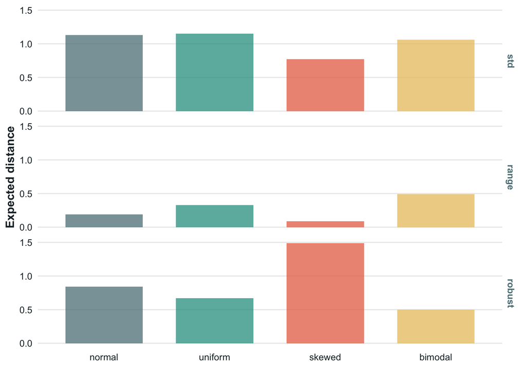

as long as variables have the same underlying distribution and scaling, commensurability holds

- skewed variables may be under- or over-contributing to the distance, depending on the scaling (range and robust, respectively)
  - the contribution of a variable to the overall distance may be biased

## Categorical distances: the delta framework<sup>1</sup>

**From categories to distances**

Let ${\bf Z}=[{\bf Z}_1,\ldots,{\bf Z}_{Q_c}]$ be the one-hot encoding of the categorical variables.

The pairwise categorical distance matrix can be written as

$${\bf D}_{c}={\bf Z}{\bf \Delta}{\bf Z}^{\sf T}=
\left[\begin{array}{ccc} {\bf Z}_{1} & \dots & {\bf Z}_{Q_{c}} \end{array} \right]\left[\begin{array}{ccc}
{\bf\Delta}_1 & & \\
& \ddots &\\
& & {\bf\Delta}_{Q_{c}} \end{array} \right] \left[ \begin{array}{c}
{\bf Z}_{1}^{\sf T}\\
\vdots \\
{\bf Z}_{Q_{c}}^{\sf T}
\end{array} \right]$$

- each ${\bf \Delta}_j$ defines the dissimilarity between the categories of variable (j)
- different choices of ${\bf \Delta}_j$ imply different categorical distance measures
- therefore, categorical distances can also suffer from scale and frequency-driven bias
[^7]: van de Velden, Iodice D’Enza, Markos, & Cavicchia (2024)

## distributions, scaling and bias: the categorical case

**flat frequency distribution**

| Distance | Cat. dissimilarity | $E[d(X_i, X_{\ell})]$ | $q=2$ | $q=5$ |
| --- | --- | --- | --- | --- |
| Matching | $\boldsymbol{\Delta}_m = \mathbf{1} \mathbf{1}^{\top} - \mathbf{I}$ | $\frac{q-1}{q}$ | 0.5 | 0.8 |
| Eskin | $\boldsymbol{\Delta}_e = \frac{2}{q^2}\boldsymbol{\Delta}_m$ | $\frac{2(q-1)}{q^3}$ | 0.250 | 0.064 |
| Occurrence frequency (OF) | $\boldsymbol{\Delta}_{OF} = \log^2(q)\boldsymbol{\Delta}_m$ | $\log^2(q)\frac{q-1}{q}$ | 0.240 | 2.072 |
| Inverse OF | $\boldsymbol{\Delta}_{IOF} = \log^2\left(\frac{I}{q}\right) \boldsymbol{\Delta}_m$ | $\log^2\left(\frac{I}{q}\right)\frac{q-1}{q}$ | 9.601 | 9.610 |

**skewed frequency distribution**

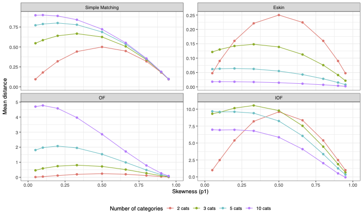

- $q\in \{2,3,5,10\}$
- $p_1 \in \{0.05,0.1,0.2,0.33, 0.5,0.66, 0.8,0.9,0.95\}$
- $p_j = (1-p_1)/(q-1)$, with $j=2,\dots,q$,

## Independence-based distances

**Independence-based pairwise distance**

No inter-variable relations are considered.

- in the continuous case: **Euclidean** or **Manhattan** distances
- in the categorical case: **Hamming** / matching distance, among many others
- in the mixed-data case: **Gower** dissimilarity index

variable contributions may be balanced, but still treated as separate sources of information

**Beyond commensurability**

commensurability makes variable contributions comparable across **scales** and data **types**.

- If variables are correlated or associated, the same information may contribute repeatedly to the distance: **redundancy**

### the next step is to account for the **structure** among variables

# 3. Association-aware distances

## by variable differences: **independence-based**

- When variables are correlated or associated, shared information is effectively counted multiple times
- inflated dissimilarities may cause potential distortions in downstream unsupervised learning tasks.

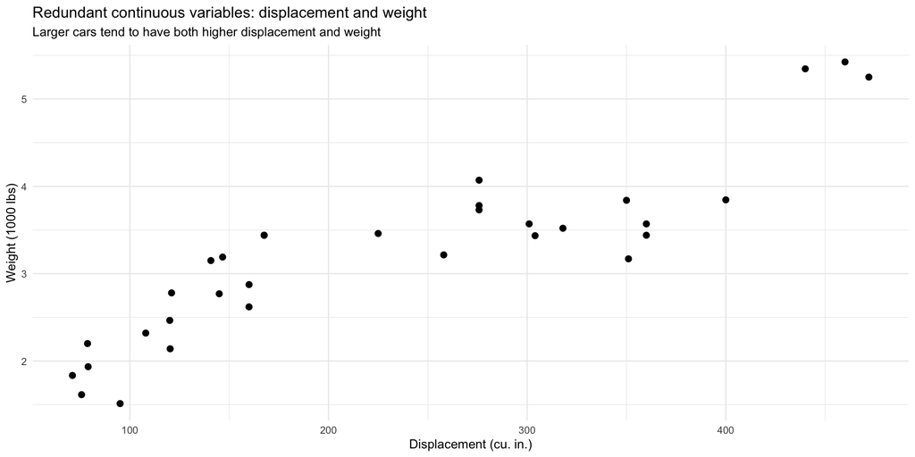

## by variable differences: **independence-based**

- When variables are correlated or associated, shared information is effectively counted multiple times
- inflated dissimilarities may cause potential distortions in downstream unsupervised learning tasks.

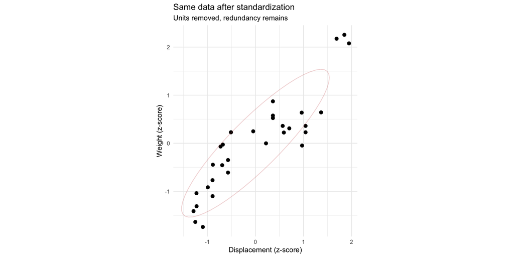

## by variable differences: **independence-based**

The Euclidean distance $\longrightarrow$ shared information is over-counted

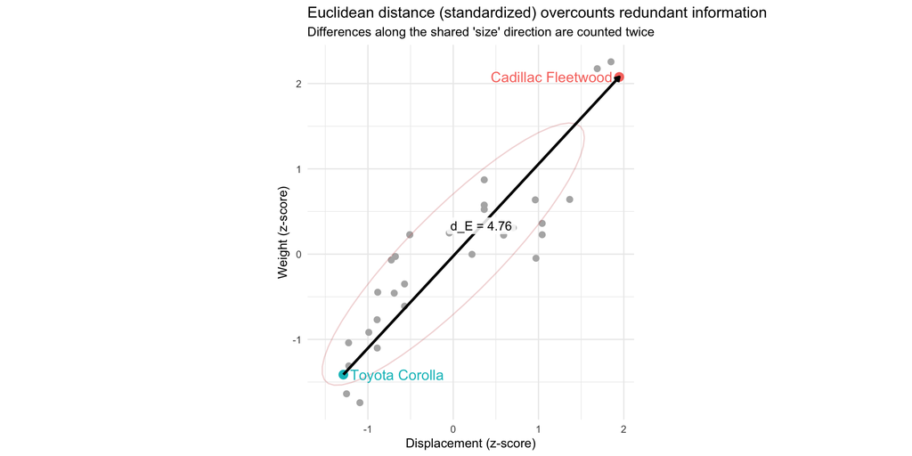

## accounting for inter-variable relations: **association-based**

The Mahalanobis distance $\longrightarrow$ shared information is not over-counted

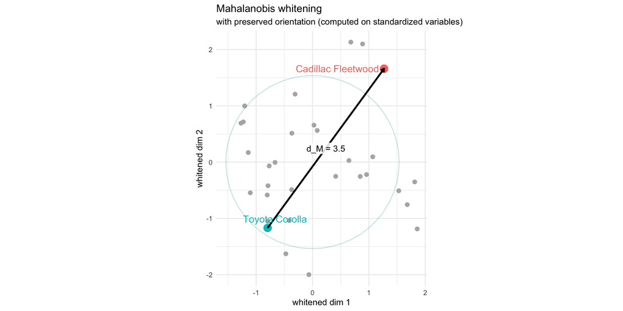

this is an **association-based** distance for continuous data

## **association-based** distance

**Association-based for continuous: Mahalanobis distance**

Let ${\bf X}_{con}$ be $n\times Q_{d}$ a data matrix of $n$ observations described by $Q_{d}$ continuous variables, and let $\bf S$ the sample covariance matrix, the Mahalanobis distance matrix is

$${\bf D}_{mah}
= \left[\operatorname{diag}({\bf G})\,{\bf 1}_{n}^{\sf T}
+ {\bf 1}_{n}\,\operatorname{diag}({\bf G})^{\sf T}
- 2{\bf G}\right]^{\odot 1/2}$$
where

- $[\cdot]^{\odot 1/2}$ denotes the element-wise square root
- ${\bf G}=({\bf C}{\bf X}_{con}){\bf S}^{-1}({\bf C}{\bf X}_{con})^{\sf T}$ is the Mahalanobis Gram matrix
- ${\bf C}={\bf I}_{n}-\tfrac{1}{n}{\bf 1}_{n}{\bf 1}_{n}^{\sf T}$ is the centering operator

## **association-based** distance

**Association-based for categorical: total variation distance (TVD)(Le & Ho, 2005)**

The distance matrix ${\bf D}_{tvd}$ can be defined via the **delta framework** upon properly defining the block-diagonal matrix ${\bf \Delta}$

Let ${\bf X}_{cat}$ be $n\times Q_{c}$ a data matrix of $n$ observations described by $Q_{c}$ categorical variables.

$${\bf D} = {\bf Z}{\Delta}{\bf Z}^{\sf T}
= \left[\begin{array}{ccc} {\bf Z}_{1} & \dots & {\bf Z}_{Q_{c}} \end{array} \right]\left[\begin{array}{ccc}
{\bf\Delta}_1 & & \\
& \ddots &\\
& & {\bf\Delta}_{Q_{c}} \end{array} \right] \left[ \begin{array}{c}
{\bf Z}_{1}^{\sf T}\\
\vdots \\
{\bf Z}_{Q_{c}}^{\sf T}
\end{array} \right]$$

- in the framework, setting ${\Delta}_j$ determines the categorical distance measure of choice (independent- or association-based)

## **association-based** distance

**Association-based for categorical: total variation distance (TVD) (Le & Ho, 2005) (2)**

Consider the empirical **joint probability** distributions stored in the off-diagonal blocks of ${\bf P}$:

$${\bf P} = \frac{1}{n}
\begin{bmatrix}
{\bf Z}_1^{\sf T}{\bf Z}_1 & {\bf Z}_1^{\sf T}{\bf Z}_2 & \cdots & {\bf Z}_1^{\sf T}{\bf Z}_{Q_c} \\
\vdots & \ddots & \vdots & \vdots \\
{\bf Z}_{Q_c}^{\sf T}{\bf Z}_1 & {\bf Z}_{Q_c}^{\sf T}{\bf Z}_2 & \cdots & {\bf Z}_{Q_c}^{\sf T}{\bf Z}_{Q_c}
\end{bmatrix}.$$

The block matrix $\bf R$ refer to the **conditional probability** distributions for each variable $j$ given each variable $i$ ($i,j=1,\ldots,Q_c$, $i\neq j$), stored in the block matrix

$${\bf R} = {\bf P}_z^{-1}({\bf P} - {\bf P}_z).$$

where ${\bf P}_z = {\bf P} \odot {\bf I}_{Q^*}$, and ${\bf I}_{Q^*}$ is the $Q^*\times Q^*$ identity matrix.

## **association-based** distance

**Association-based for categorical: total variation distance (TVD)(Le & Ho, 2005) (3)**

Let ${\bf r}^{ji}_a$ and ${\bf r}^{ji}_b$ be the rows of ${\bf R}_{ji}$, the $(j,i)$th off-diagonal block of ${\bf R}$.

The category dissimilarity between $a$ and $b$ for variable $j$ based on the total variation distance (TVD) is defined as

$$\delta^{j}_{tvd}(a,b)
= \sum_{i\neq j}^{Q_c} w_{ji}
\Phi^{ji}({\bf r}^{ji}_{a},{\bf r}^{ji}_{b})
= \sum_{i\neq j}^{Q_c} w_{ji}
\left[\frac{1}{2}\sum_{\ell=1}^{q_i}
|{\bf r}^{ji}_{a\ell}-{\bf r}^{ji}_{b\ell}|\right],
\label{ab_delta}$$

where $w_{ji}=1/(Q_c-1)$ for equal weighting (can be user-defined).

TVD-based dissimilarity matrix is, therefore,

$${\bf D}_{tvd}= {\bf Z}{\Delta}^{(tvd)}{\bf Z}^{\sf T}.$$

## **association-based** distance: a small example

**Data**

Consider two categorical variables:

- $X_1$ with categories $A,B,C$
- $X_2$ with categories $u,v$

```
# A tibble: 10 × 3
      id X1    X2
   <int> <fct> <fct>
 1     1 A     u
 2     2 A     u
 3     3 A     v
 4     4 B     u
 5     5 B     u
 6     6 B     v
 7     7 C     u
 8     8 C     v
 9     9 C     v
10    10 C     v
```

**Indicator matrices**

$${\bf Z}_1 =
\begin{pmatrix}
1&0&0\\
1&0&0\\
1&0&0\\
0&1&0\\
0&1&0\\
0&1&0\\
0&0&1\\
0&0&1\\
0&0&1\\
0&0&1
\end{pmatrix},
\qquad
{\bf Z}_2 =
\begin{pmatrix}
1&0\\
1&0\\
0&1\\
1&0\\
1&0\\
0&1\\
1&0\\
0&1\\
0&1\\
0&1
\end{pmatrix}.$$

## **association-based** distance: from ${\bf Z}$ to ${\bf P}$

Let

$${\bf Z} = [{\bf Z}_1,{\bf Z}_2].$$

The empirical co-occurrence matrix is

$${\bf P}
=
\frac{1}{10}{\bf Z}^{\sf T}{\bf Z}.$$

For this example,

$${\bf P}
=
\begin{pmatrix}
\color{#2A9D8F}{0.30} & \color{#2A9D8F}{0} & \color{#2A9D8F}{0} & \color{#E76F51}{0.20} & \color{#E76F51}{0.10}\\
\color{#2A9D8F}{0} & \color{#2A9D8F}{0.30} & \color{#2A9D8F}{0} & \color{#E76F51}{0.20} & \color{#E76F51}{0.10}\\
\color{#2A9D8F}{0} & \color{#2A9D8F}{0} & \color{#2A9D8F}{0.40} & \color{#E76F51}{0.10} & \color{#E76F51}{0.30}\\
\color{#E76F51}{0.20} & \color{#E76F51}{0.20} & \color{#E76F51}{0.10} & \color{#2A9D8F}{0.50} & \color{#2A9D8F}{0}\\
\color{#E76F51}{0.10} & \color{#E76F51}{0.10} & \color{#E76F51}{0.30} & \color{#2A9D8F}{0} & \color{#2A9D8F}{0.50}
\end{pmatrix}.$$

### diagonal blocks contain marginal information; off-diagonal blocks contain joint proportions

## **association-based** distance: from ${\bf P}$ to ${\bf R}$

The diagonal part of ${\bf P}$ is

$${\bf P}_z
=
{\bf P} \odot {\bf I}_{Q^*}
=
\operatorname{diag}(0.30,0.30,0.40,0.50,0.50).$$

The block matrix of conditional profiles is

$${\bf R}
=
{\bf P}_z^{-1}({\bf P}-{\bf P}_z).$$

For this example,

$${\bf R}
=
\begin{pmatrix}
\color{#2A9D8F}{0} & \color{#2A9D8F}{0} & \color{#2A9D8F}{0} & \color{#E76F51}{0.67} & \color{#E76F51}{0.33}\\
\color{#2A9D8F}{0} & \color{#2A9D8F}{0} & \color{#2A9D8F}{0} & \color{#E76F51}{0.67} & \color{#E76F51}{0.33}\\
\color{#2A9D8F}{0} & \color{#2A9D8F}{0} & \color{#2A9D8F}{0} & \color{#E76F51}{0.25} & \color{#E76F51}{0.75}\\
\color{#E76F51}{0.40} & \color{#E76F51}{0.40} & \color{#E76F51}{0.20} & \color{#2A9D8F}{0} & \color{#2A9D8F}{0}\\
\color{#E76F51}{0.20} & \color{#E76F51}{0.20} & \color{#E76F51}{0.60} & \color{#2A9D8F}{0} & \color{#2A9D8F}{0}
\end{pmatrix}.$$

### each off-diagonal block contains conditional profiles across variables

## **association-based** distance: reading ${\bf R}_{12}$

For the categories of $X_1$, the relevant block is

$${\bf R}_{12}
=
\begin{pmatrix}
0.67 & 0.33\\
0.67 & 0.33\\
0.25 & 0.75
\end{pmatrix}.$$

**Interpretation**

Rows of ${\bf R}_{12}$ describe the distribution of $X_2$ within each category of $X_1$:

- category $A$: $P(X_2=u \mid X_1=A)=0.67$, $P(X_2=v \mid X_1=A)=0.33$
- category $B$: $P(X_2=u \mid X_1=B)=0.67$, $P(X_2=v \mid X_1=B)=0.33$
- category $C$: $P(X_2=u \mid X_1=C)=0.25$, $P(X_2=v \mid X_1=C)=0.75$

### categories are compared through their association profiles

## **association-based** distance: from ${\bf R}$ to $\Delta_1^{(tvd)}$

Compare the rows of ${\bf R}_{12}$ using TVD.

$$\delta^{1}_{tvd}(A,B)
=
\frac{1}{2}
\left(
|0.67-0.67| + |0.33-0.33|
\right)
=
0.$$

$$\delta^{1}_{tvd}(A,C)
=
\frac{1}{2}
\left(
|0.67-0.25| + |0.33-0.75|
\right)
=
0.42.$$

$$\delta^{tvd}_{1}(B,C)
=
0.42.$$

Therefore,

$$\Delta^{(tvd)}_1
=
\begin{pmatrix}
0 & 0 & 0.42\\
0 & 0 & 0.42\\
0.42 & 0.42 & 0
\end{pmatrix}.$$

### $A$ and $B$ are close because they have the same profile with respect to $X_2$

## **association-based** distance: reading ${\bf R}_{21}$

For the categories of $X_2$, the relevant block is

$${\bf R}_{21}
=
\begin{pmatrix}
0.40 & 0.40 & 0.20\\
0.20 & 0.20 & 0.60
\end{pmatrix}.$$

**Interpretation**

Rows of ${\bf R}_{21}$ describe the distribution of $X_1$ within each category of $X_2$:

- category $u$: $P(X_1=A \mid X_2=u)=0.40$, $P(X_1=B \mid X_2=u)=0.40$, $P(X_1=C \mid X_2=u)=0.20$
- category $v$: $P(X_1=A \mid X_2=v)=0.20$, $P(X_1=B \mid X_2=v)=0.20$, $P(X_1=C \mid X_2=v)=0.60$

### categories of $X_2$ are compared through their association profiles with respect to $X_1$

## **association-based** distance: from ${\bf R}_{21}$ to $\Delta_2^{(tvd)}$

Compare the rows of ${\bf R}_{21}$ using TVD.

$$\delta^{tvd}_{1}(u,v)
=
\frac{1}{2}
\left(
|0.40-0.20| + |0.40-0.20| + |0.20-0.60|
\right)
=
0.40.$$

Therefore,

$$\Delta^{(tvd)}_2
=
\begin{pmatrix}
0 & 0.40\\
0.40 & 0
\end{pmatrix}.$$

### $u$ and $v$ are different because they imply different profiles over $X_1$

## **association-based** distance: from $\Delta$ to ${\bf D}$

We collect the category dissimilarity matrices in a block-diagonal matrix:

$$\Delta^{(tvd)}
=
\begin{pmatrix}
\color{#2A9D8F}{\Delta^{(tvd)}_1} & \color{#E76F51}{0}\\
\color{#E76F51}{0} & \color{#2A9D8F}{\Delta^{(tvd)}_2}
\end{pmatrix}.$$

The observation-level categorical distance matrix is then

$${\bf D}_{tvd}
=
{\bf Z}\Delta^{(tvd)}{\bf Z}^{\sf T}
=
\begin{bmatrix}
{\bf Z}_1 & {\bf Z}_2
\end{bmatrix}
\begin{pmatrix}
\Delta^{(tvd)}_1 & 0\\
0 & \Delta^{(tvd)}_2
\end{pmatrix}
\begin{bmatrix}
{\bf Z}_1^{\sf T}\\
{\bf Z}_2^{\sf T}
\end{bmatrix}.$$

Equivalently,

$${\bf D}_{tvd}
=
{\bf Z}_1\Delta^{(tvd)}_1{\bf Z}_1^{\sf T}
+
{\bf Z}_2\Delta^{(tvd)}_2{\bf Z}_2^{\sf T}.$$

### category-level dissimilarities are translated into observation-level distances

## From distances to data representation

Different distance definitions induce different **distance-based representations** of the same data.

**Same data, different representation**

Changing the distance changes the **global dissimilarity structure** on which downstream learning methods rely.

**Leave-one-variable-out diagnostics**

How can we measure the contribution of each variable to this structure?

- compare the dissimilarity matrix computed with and without the variable in question

## LOVO-based benchmark: evaluated distances

The benchmark compares distance definitions that differ in how they treat **scale**, **type**, **additivity**, and **association**.

**Additive distances**

- `gower`: classical Gower dissimilarity
- `mod_gower`: modified Gower coefficients (Liu et al., 2024)
- `hl_add`: additive version of Hennig–Liao scaling (Hennig & Liao, 2013)
- `u_ind`: unbiased independence-based distance
- `u_dep`: unbiased association-based distance
- `u_mix`: unbiased Manhattan and TVD

**Non-additive distances**

- `naive`: Euclidean distance on scaled numerical variables and one-hot-encoded
- `hl`: Hennig–Liao scaling with Euclidean distance
- `gudmm`: generalized multi-aspect distance metric for mixed-type data (Mousavi & Sehhati, 2023)
- `dkps`: distance using kernel product similarity (Ghashti & Thompson, 2025)

## LOVO-based diagnostics: what is evaluated?

For each distance and each variable $X_j$, we compare the full-data representation ${\bf D}$ with the representation obtained after removing $X_j$, that is ${\bf D}_{-j}$.

**1. Distance level**

Numeric comparision between ${\bf D}$ and ${\bf D}_{-j}$.

- **mean absolute difference** between distance matrices.

**2. MDS level**

Compute MDS from ${\bf D}$ and from ${\bf D}_{-j}$, then compare the resulting configurations.

- **alienation coefficient** between MDS representations.

### LOVO diagnostics assess how each variable contributes to the dissimilarity structure

## LOVO diagnostics: distance-level effect

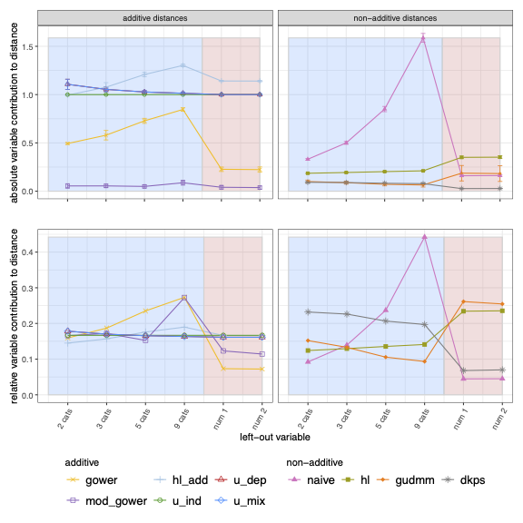

## LOVO diagnostics: MDS-level effect

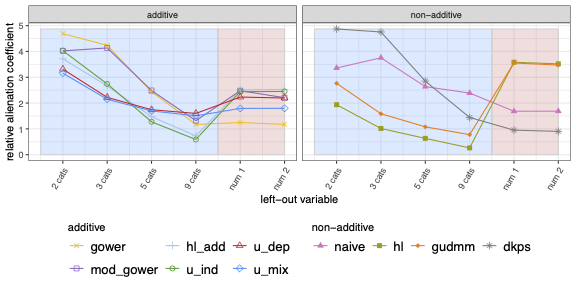

- commensurability balances expected distance contributions, not necessarily the role of variables in every downstream representation

## From diagnostics to downstream learning

LOVO diagnostics show how variables affect the distance matrix and the MDS representation.

But we also want to know whether distance biases affect a downstream learning task.

**Unsupervised classification experiment**

Use each distance matrix as input to PAM and evaluate how well the resulting partition recovers the known cluster structure.

## Unsupervised classification experiment

**Data generation**

- (n = 200) observations from (4) equal-sized clusters
- data generated with `genRandomClust`
- each dataset contains (8) numerical and (8) categorical variables
- categorical variables are obtained by discretizing numerical variables into (9) categories
- scenarios vary the number of signal and noise variables within each type
- (100) datasets are generated for each scenario

**Evaluation**

For each mixed-data distance, PAM is applied to the dissimilarity matrix with (K = 4).  
Recovery of the true cluster labels is measured using the adjusted Rand index.

## PAM-based clustering results

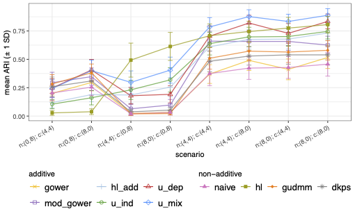

- `hl` performs well when categorical variables are noise, but poorly when numerical variables are noise
- `gower` tends to show the opposite pattern
- `u_mix` and `u_dep` are comparatively stable in the mixed signal/noise scenarios

# 4. Interaction- and response-aware extensions

## Interaction-aware distances

Association-aware distances account for relations **within** variable blocks:

- continuous–continuous relations;
- categorical–categorical relations.

**Cross-type structure**

In mixed data, categorical differences may be meaningful because they are reflected in the continuous variables.

### the next step is to make distances interaction-aware

## How to measure interactions<sup>1</sup>

Define $\Delta^{int}$ to account for continuous–categorical interactions and use it to augment $\Delta^{tvd}$.

The mixed dissimilarity becomes

$${\bf D}_{mix}^{(int)}
=
{\bf D}_{mah}
+
{\bf D}_{cat}^{(int)}.$$

where

$${\bf D}_{cat}^{(int)}={\bf Z}\tilde{\Delta}{\bf Z}^\top$$

and

$$\tilde{\Delta} = (1-\alpha)\Delta^{tvd} + \alpha \Delta^{int},
\qquad
\alpha=\frac{1}{Q_c}.$$

[^8]: Iodice D’Enza, Tortora, & Palumbo (2026)

## What is $\Delta^{int}$?

The entry $\delta_{int}^{j}(a,b)$ measures how much the continuous variables help discriminate between observations choosing category $a$ and those choosing category $b$ for categorical variable $j$.

**Category-pair classification problem**

For each pair $(a,b)$:

- use the continuous variables as predictors;
- classify observations belonging to categories $a$ and $b$;
- use a nearest-neighbour rule in the continuous space.

## Computing $\Delta^{int}_{j}$

For each categorical variable $j$ and each pair of categories $(a,b)$:

1. use ${\bf D}_{mah}$ to identify neighbours in the continuous space;
2. consider a proportion of neighbours, say $\hat{\pi}_{nn}=0.1$;
3. classify observations using a prior-corrected decision rule;
4. compute balanced accuracy.

$$\delta_{int}^{j}(a,b)
=
\frac{1}{2}
\left(
\frac{\texttt{true } a}{\texttt{true } a + \texttt{false } a}
+
\frac{\texttt{true } b}{\texttt{true } b + \texttt{false } b}
\right).$$

## Well separated or not?

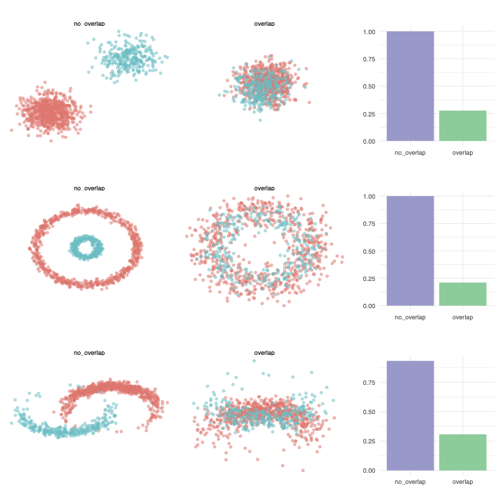

### high separability $\Rightarrow$ high interaction dissimilarity

## Building $\Delta^{int}_{j}$

For categorical variable $j$ with $q_j$ categories, compute  
$\frac{q_j(q_j -1)}{2}$ category-pair quantities.

$$\Delta_{int} =
\begin{pmatrix}
0 & \cdot & \cdot & \cdot \\
\cdot & 0 & \cdot & \cdot \\
\cdot & \cdot & 0 & \cdot\\
\cdot & \cdot & \cdot & 0
\end{pmatrix}$$

## Building $\Delta^{int}_{j}$

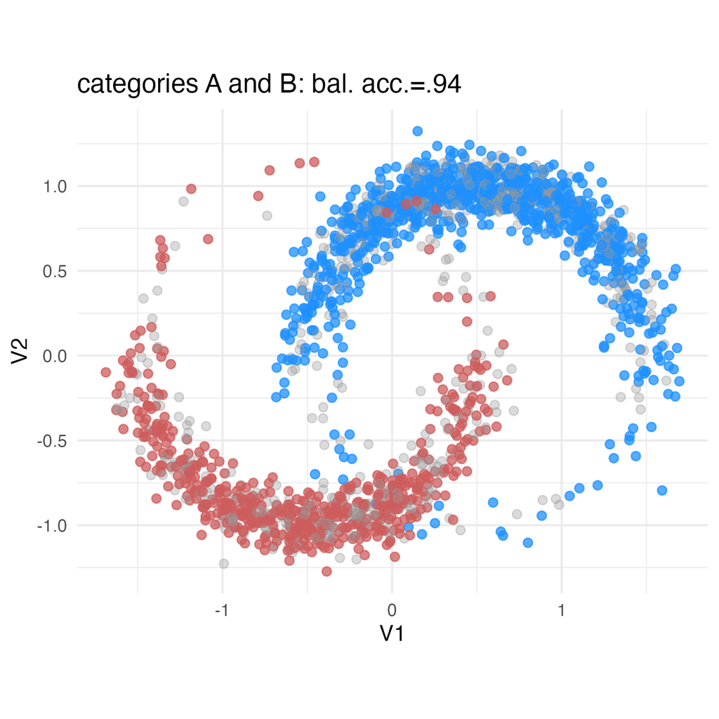

$$\Delta_{int} =
\begin{pmatrix}
0 & \color{#E76F51}{0.94} & \cdot & \cdot \\
\color{#E76F51}{0.94} & 0 & \cdot & \cdot \\
\cdot & \cdot & 0 & \cdot\\
\cdot & \cdot & \cdot & 0
\end{pmatrix}$$

## Building $\Delta^{int}_{j}$

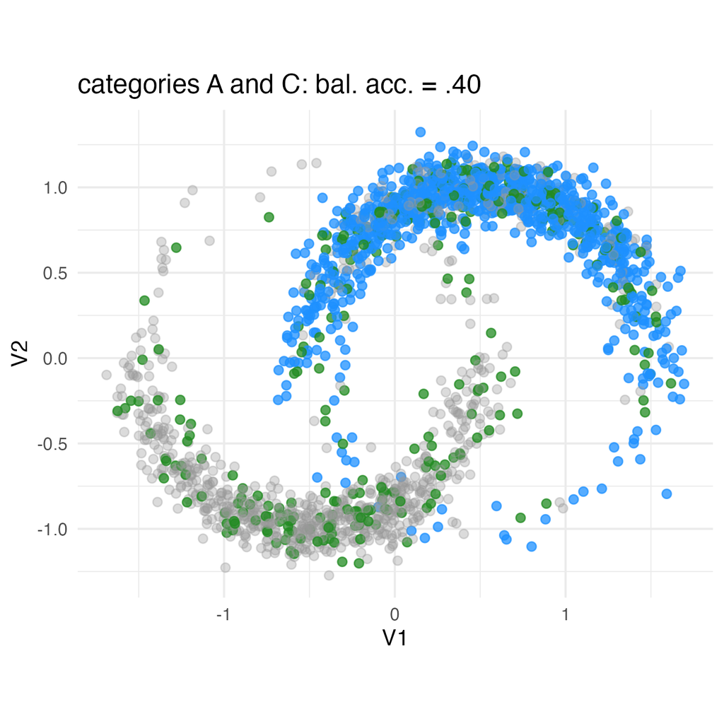

$$\Delta_{int} =
\begin{pmatrix}
0 & 0.94 & \color{#E76F51}{0.40} & \cdot \\
0.94 & 0 & \cdot & \cdot \\
\color{#E76F51}{0.40} & \cdot & 0 & \cdot\\
\cdot & \cdot & \cdot & 0
\end{pmatrix}$$

## Building $\Delta^{int}_{j}$

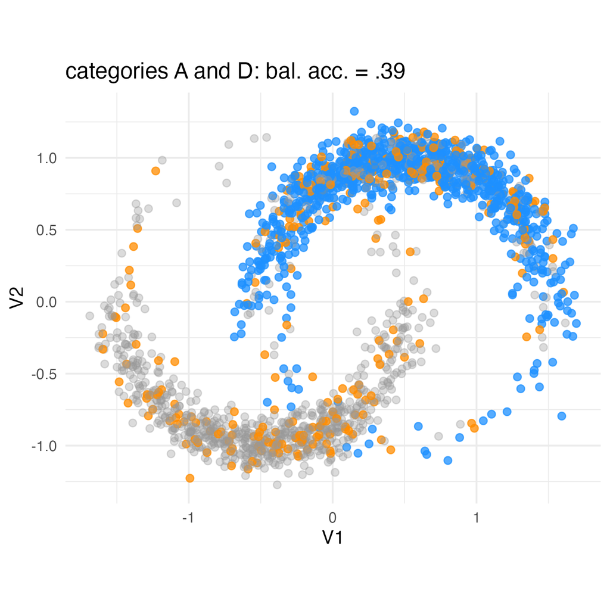

$$\Delta_{int} =
\begin{pmatrix}
0 & 0.94 & 0.40 & \color{#E76F51}{0.39} \\
0.94 & 0 & \cdot & \cdot \\
0.40 & \cdot & 0 & \cdot\\
\color{#E76F51}{0.39} & \cdot & \cdot & 0
\end{pmatrix}$$

## Building $\Delta^{int}_{j}$

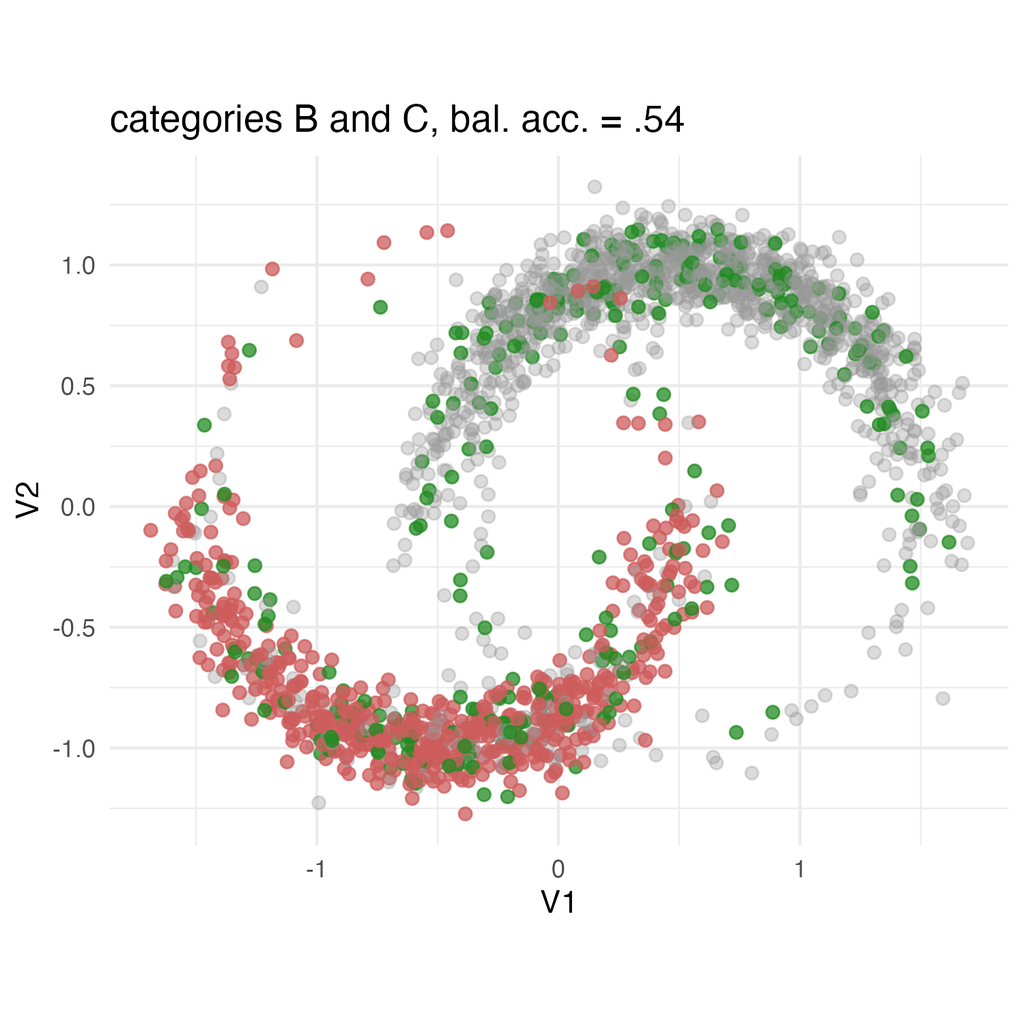

$$\Delta_{int} =
\begin{pmatrix}
0 & 0.94 & 0.40 & 0.39 \\
0.94 & 0 & \color{#E76F51}{0.54} & \cdot \\
0.40 & \color{#E76F51}{0.54} & 0 & \cdot \\
0.39 & \cdot & \cdot & 0
\end{pmatrix}$$

## Building $\Delta^{int}_{j}$

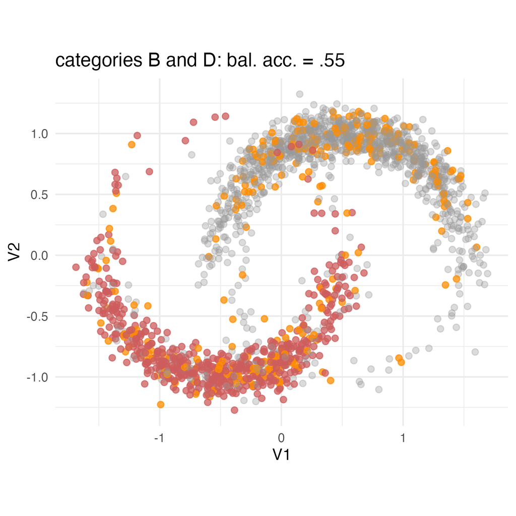

$$\Delta_{int} =
\begin{pmatrix}
0 & 0.94 & 0.40 & 0.39 \\
0.94 & 0 & 0.54 & \color{#E76F51}{0.55} \\
0.40 & 0.54 & 0 & \cdot \\
0.39 & \color{#E76F51}{0.55} & \cdot & 0
\end{pmatrix}$$

## Building $\Delta^{int}_{j}$

[figure not shown]

$$\Delta_{int} =
\begin{pmatrix}
0 & 0.94 & 0.40 & 0.39 \\
0.94 & 0 & 0.54 & 0.55 \\
0.40 & 0.54 & 0 & \color{#E76F51}{0} \\
0.39 & 0.55 & \color{#E76F51}{0} & 0
\end{pmatrix}$$

### the interaction matrix summarizes category-pair separability in the continuous space

## Why this interaction is asymmetric

We model the joint structure as

$$f({\bf x}_{con},{\bf x}_{cat})
=
f({\bf x}_{con})
f({\bf x}_{cat}\mid {\bf x}_{con}).$$

The interaction term asks how categorical distinctions are reflected in the continuous geometry.

## Spectral clustering: a graph partitioning problem

**Graph representation**

A graph representation of the data matrix ${\bf X}$: the aim is to cut it into $K$ groups, or clusters.

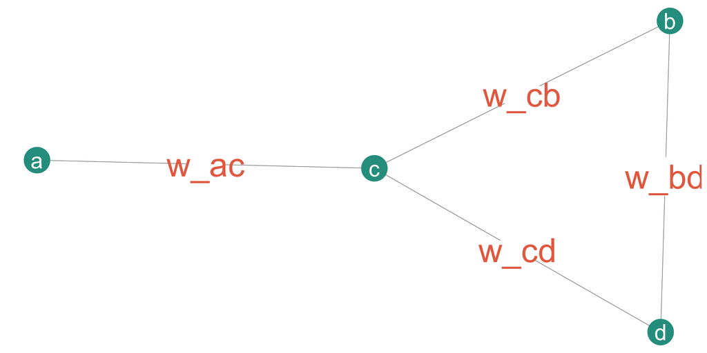

**The affinity matrix ${\bf A}$**

The elements ${\bf w}_{ij}$ of ${\bf A}$ are high when observations $i$ and $j$ are likely to belong to the same group, and low otherwise.

| . | a | b | c | d |
| --- | --- | --- | --- | --- |
| a | 0 | 0 | w_ac | 0 |
| b | 0 | 0 | w_cb | w_bd |
| c | w_ca | w_cb | 0 | w_cd |
| d | 0 | w_db | w_dc | 0 |

## Spectral clustering: making the graph easy to cut

An approximate solution to the graph partitioning problem:

**From distances to affinities**

Start from the pairwise distance matrix ${\bf D}$ and build the affinity matrix

$${\bf A}
=
\exp\left(-\frac{{\bf D}^{2}}{2\sigma^{2}}\right),
\qquad a_{ii}=0.$$

The parameter $\sigma$ controls the neighbourhood scale.

**Normalized graph Laplacian**

The normalized affinity matrix is

$${\bf L}
=
{\bf D}_{r}^{-1/2}
{\bf A}
{\bf D}_{r}^{-1/2}
=
{\bf Q}{\Lambda}{\bf Q}^{\sf T},$$

where ${\bf D}_{r}=\operatorname{diag}({\bf r})$, ${\bf r}={\bf A}{\bf 1}$, ${\bf 1}$ is an $n$-dimensional vector of ones.

**Spectral embedding**

The spectral clustering solution is obtained by applying $K$-means to the rows of  
${\bf \tilde Q}$, the matrix containing the first $K$ eigenvectors of ${\bf L}$.

## Why spectral clustering here?

Interaction-aware distances can encode local connectivity and non-convex structure.

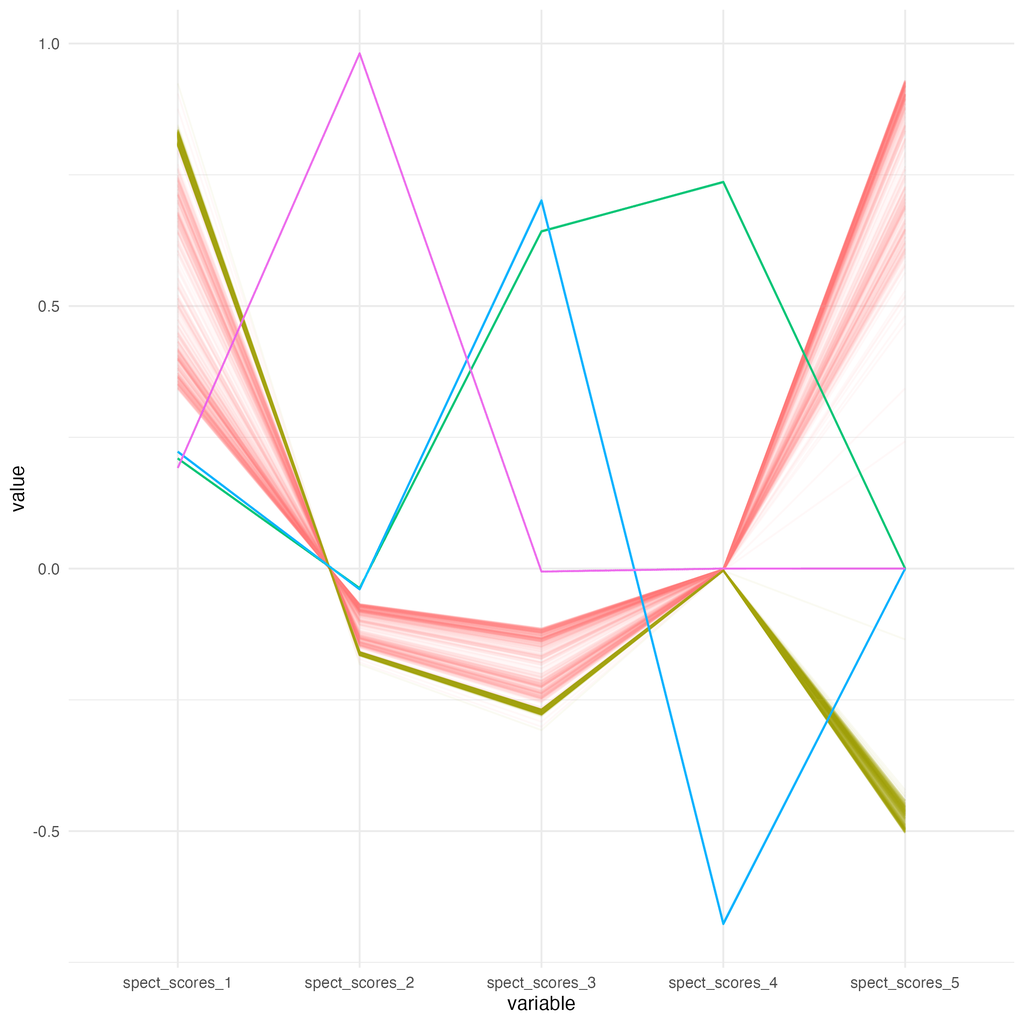

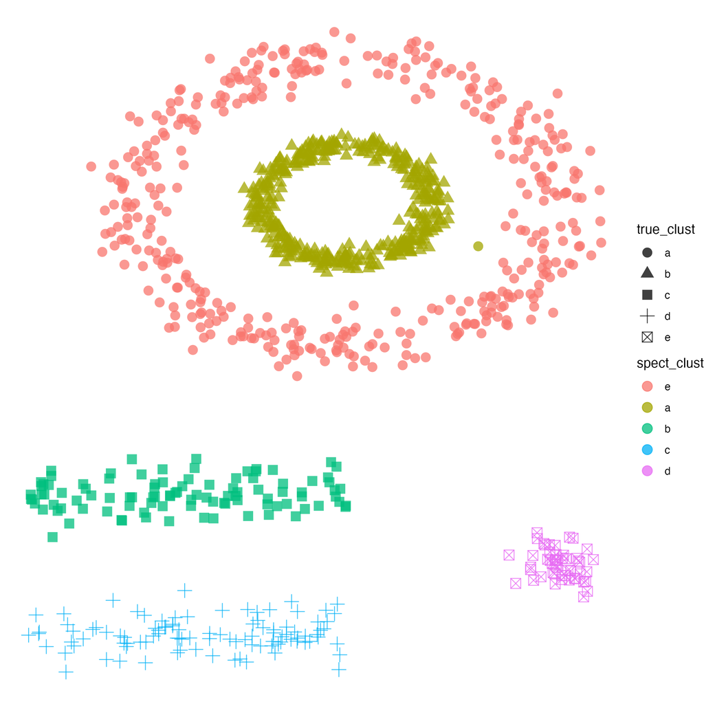

## Experiment: interaction-driven clusters

**Design**

- $n=500$ and $n=1000$
- six continuous variables: $V_1,\ldots,V_6$
- three categorical variables: $C_1,C_2,C_3$
- $V_4,V_5,V_6$ generated independently from $N(0,1)$
- $V_1,V_2,V_3$ generated conditionally on $C_1$ and $C_2$

**Main feature**

The clusters are not defined by continuous variables alone or categorical variables alone,  
but by their **cross-type interaction**.

## Interaction-aware spectral clustering results

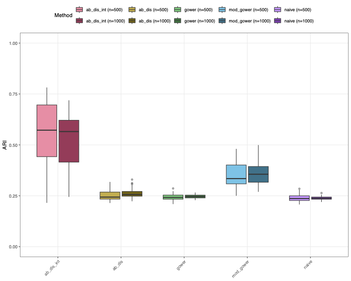

## Main references

Iodice D’Enza, A., Tortora, C., & Palumbo, F. (2026). Association-based spectral clustering for mixed data with cross-type interactions. *Manuscript Submitted to Statistics and Computing*.

van de Velden, M., Iodice D’Enza, A., Markos, A., & Cavicchia, C. (2026). A general framework for unbiased mixed-variables distances. *Under Review: Journal of Computational and Graphical Statistics*.

Ghashti, J. S., & Thompson, J. R. J. (2025). Mixed-type distance shrinkage and selection for clustering via kernel metric learning. *Journal of Classification*, *42*(2), 311–334.

Liu, P., Yuan, H., Ning, Y., Chakraborty, B., Liu, N., & Peres, M. A. (2024). A modified and weighted gower distance-based clustering analysis for mixed type data: A simulation and empirical analyses. *BMC Medical Research Methodology*, *24*(305).

van de Velden, M., Iodice D’Enza, A., Markos, A., & Cavicchia, C. (2024). A general framework for implementing distances for categorical variables. *Pattern Recognition*, *153*, 110547.

Mousavi, E., & Sehhati, M. (2023). A generalized multi-aspect distance metric for mixed-type data clustering. *Pattern Recognition*, 109353.

Hennig, C., & Liao, T. F. (2013). How to Find an Appropriate Clustering for Mixed-Type Variables with Application to Socio-Economic Stratification. *Journal of the Royal Statistical Society Series C: Applied Statistics*, *62*(3), 309–369.

Kaufman, L., & Rousseeuw, P. J. (2009). *Finding groups in data: An introduction to cluster analysis*. John Wiley & Sons.

Borg, I., & Groenen, P. J. (2005). *Modern multidimensional scaling: Theory and applications*. Springer.

Le, S. Q., & Ho, T. B. (2005). An association-based dissimilarity measure for categorical data. *Pattern Recognition Letters*, *26*(16), 2549–2557.

Ng, A. Y., Jordan, M. I., & Weiss, Y. (2002). On spectral clustering: Analysis and an algorithm. *Advances in Neural Information Processing Systems*, *14*, 849–856. MIT Press.

## Contact and slides

### Contact

Alfonso Iodice D’Enza  
iodicede@unina.it

### GitHub Pages

https://alfonsoiodicede.github.io

### scan to open the slides

[figure not shown]